# GLM Part5

Murray Logan

08 August, 2022

# Preparations

Load the necessary libraries

```r
library(car) # for regression diagnostics
library(broom) # for tidy output
library(ggfortify) # for model diagnostics
library(sjPlot) # for outputs
library(knitr) # for kable
library(effects) # for partial effects plots
library(emmeans) # for estimating marginal means
library(ggeffects) # for plotting marginal means
library(MASS) # for glm.nb
library(MuMIn) # for AICc
library(tidyverse) # for data wrangling
library(modelr) # for auxillary modelling functions
library(performance) # for residuals diagnostics
library(see) # for plotting residuals
library(DHARMa) # for residual diagnostics plots
library(patchwork) # grid of plots
library(scales) # for more scales
```

# Scenario

Here is a modified example from Quinn and Keough (2002). Day and Quinn (1989) described an experiment that examined how rock surface type affected the recruitment of barnacles to a rocky shore. The experiment had a single factor, surface type, with 4 treatments or levels: algal species 1 (ALG1), algal species 2 (ALG2), naturally bare surfaces (NB) and artificially scraped bare surfaces (S). There were 5 replicate plots for each surface type and the response (dependent) variable was the number of newly recruited barnacles on each plot after 4 weeks.

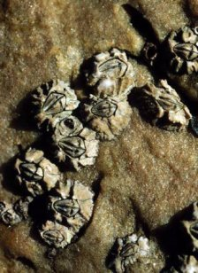

Six-plated barnacle

Format of day.csv data files

| TREAT | BARNACLE |
| --- | --- |
| ALG1 | 27 |
| .. | .. |
| ALG2 | 24 |
| .. | .. |
| NB | 9 |
| .. | .. |
| S | 12 |
| .. | .. |

| **TREAT** | Categorical listing of surface types. ALG1 = algal species 1, ALG2 = algal species 2, NB = naturally bare surface, S = scraped bare surface. |
| --- | --- |
| **BARNACLE** | The number of newly recruited barnacles on each plot after 4 weeks. |

# Read in the data

As we are going to treat Treatment as a categorical predictor, we will specifically declare it as such straight after importing the data.

```r
day <- read_csv("../public/data/day.csv", trim_ws = TRUE)
glimpse(day)
```

```
## Rows: 20
## Columns: 2
## $ TREAT    <chr> "ALG1", "ALG1", "ALG1", "ALG1", "ALG1", "ALG2", "ALG2", "ALG2…
## $ BARNACLE <dbl> 27, 19, 18, 23, 25, 24, 33, 27, 26, 32, 9, 13, 17, 14, 22, 12…
```

```r
day <- day %>%
  mutate(TREAT = factor(TREAT))
```

# Exploratory data analysis

Model formula:
$$y_i \sim{} \mathcal{Pois}(\lambda_i)\\
\mu_i = \boldsymbol{\beta} \bf{X_i}$$

where $\boldsymbol{\beta}$ is a vector of effects parameters and $\bf{X}$ is a model matrix representing the intercept and treatment contrasts for the effects of Treatment on barnacle recruitment.

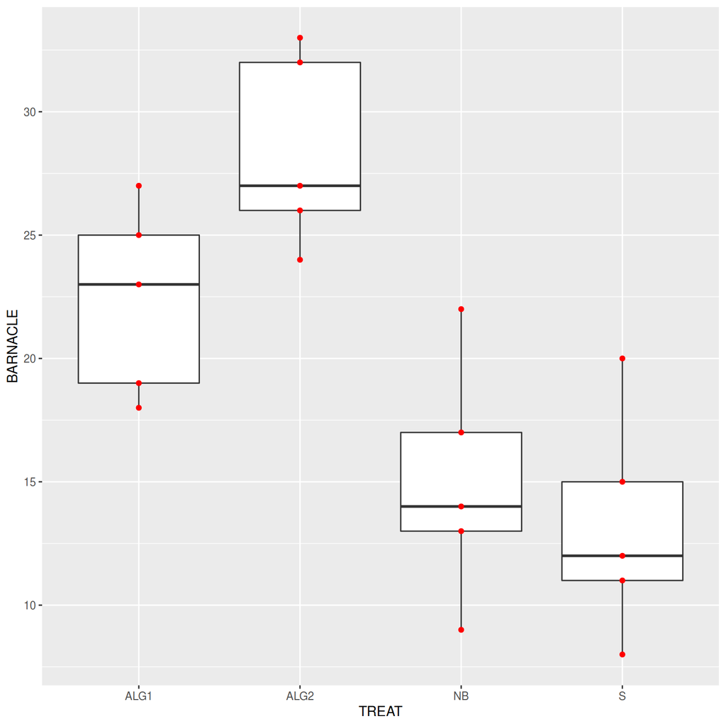

```r
ggplot(day, aes(y = BARNACLE, x = TREAT)) +
  geom_boxplot() +
  geom_point(color = "red")
```

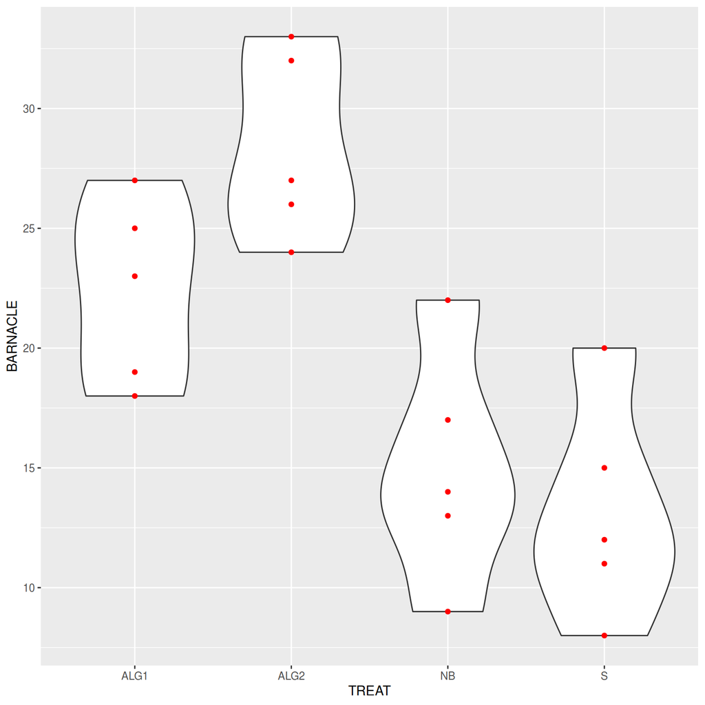

```r
ggplot(day, aes(y = BARNACLE, x = TREAT)) +
  geom_violin() +
  geom_point(color = "red")
```

# Fit the model

Categorical predictors are actually treated as multiple regression. We start by dummy coding the levels into separate vectors containing only 0’s and 1’s. The following fabricated example should illustrate this process. The first column represent a response (the numbers are not important for the dummy coding and thus they are excluded from the example). Column X represents a categorical variable with three levels (A, B and C). This could be dummy coded into three dummies (one for each level of the categorical predictor).

| Y | X | Dummy 1 | Dummy 2 | Dummy 3 |
| --- | --- | --- | --- | --- |
| . | A | 1 | 0 | 0 |
| . | A | 1 | 0 | 0 |
| . | B | 0 | 1 | 0 |
| . | B | 0 | 1 | 0 |
| . | C | 0 | 0 | 1 |
| . | C | 0 | 0 | 1 |

So, we could construct the linear predictor of a regression model as:

$$log(\mu_i) = \beta_0 + \beta_1 D1 + \beta_2 D2 + \beta_3 D3$$

however, this would be an overparameterized model as there are four effects parameters to estimate from only three chunks of data (one per level of the categorical predictor).

One option would be to drop the intercept:

$$log(\mu_i) = \beta_1 D1 + \beta_2 D2 + \beta_3 D3$$
Now each $\beta$ just represents the mean of each level of the categorical predictor. Although this is perfectly valid, it is not a common way to express the model as it does not include any effects (differences).

Another option is to re-parameterise this model such that the intercept represents the mean of the first level of the categorical predictor and then two additional $\beta$ parameters represent the differences between the first level and each of the remaining levels. This parameterisation is called **treatment contrasts**.

When we fit treatment contrasts, the first dummy variable is populated with 1’s.

| Y | X | Dummy 1 | Dummy 2 | Dummy 3 |
| --- | --- | --- | --- | --- |
| . | A | 1 | 0 | 0 |
| . | A | 1 | 0 | 0 |
| . | B | 1 | 1 | 0 |
| . | B | 1 | 1 | 0 |
| . | C | 1 | 0 | 1 |
| . | C | 1 | 0 | 1 |

$$log(\mu_i) = \beta_0 + \beta_2 D2 + \beta_3 D3$$

Before actually fitting the model for our actual data, it might be instructive to estimate the effects via matrix multiplication so as to see the treatment contrasts in action. Note, this approach is essentially Ordinary Least Squares regression, as and as such, assumes normality and homogeneity of variance. As the response observations are counts, a Gaussian distribution might bot be the most appropriate choice. Nevertheless, it will suffice for the purpose of illustration.

```r
# Effects model
## start by dummy coding the categorical predictor and expressing
## the treatment effects as a model matrix.
Xmat <- model.matrix(~TREAT, data = day)
Xmat %>% head()
```

```
##   (Intercept) TREATALG2 TREATNB TREATS
## 1           1         0       0      0
## 2           1         0       0      0
## 3           1         0       0      0
## 4           1         0       0      0
## 5           1         0       0      0
## 6           1         1       0      0
```

```r
## latex-math-preview-expression
# solve(X'X)X'Y
solve(t(Xmat) %*% Xmat) %*% t(Xmat) %*% day$BARNACLE
```

```
##             [,1]
## (Intercept) 22.4
## TREATALG2    6.0
## TREATNB     -7.4
## TREATS      -9.2
```

Now lets fit the model. As the response observations are counts, a Poisson distribution would be an obvious choice for the model distribution. That said, it might be useful to fit the model with a Gaussian distribution with an Identity link (no transformation) to assist us in interpreting the estimated coefficients. TO emphasise, the Gaussian model will only be used as a learning aid, as a model, it does not have as much merit as a Poisson model.

```r
day.glm <- glm(BARNACLE ~ TREAT, data = day, family = "gaussian")
day.glm1 <- glm(BARNACLE ~ TREAT, data = day, family = "poisson")
day.glm1 <- glm(BARNACLE ~ TREAT, data = day, family = poisson(link = "log"))
```

# Model validation

## autoplot

### Gaussian

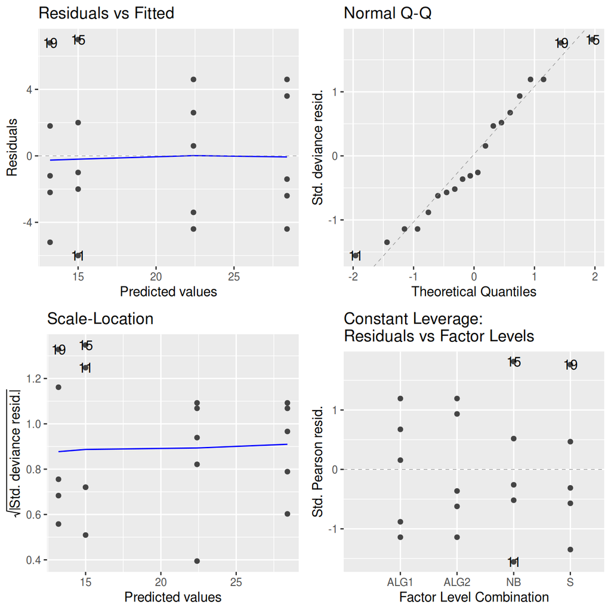

```r
day.glm %>% autoplot()
```

**Conclusion:**

- there is not much alarming here
- note, there is no value in displaying leverage and leverage based diagnostics since leverage does not make much sense from categorical predictors. An observation must be in one of the levels - they cannot really be an outlier in this dimension.

### Poisson

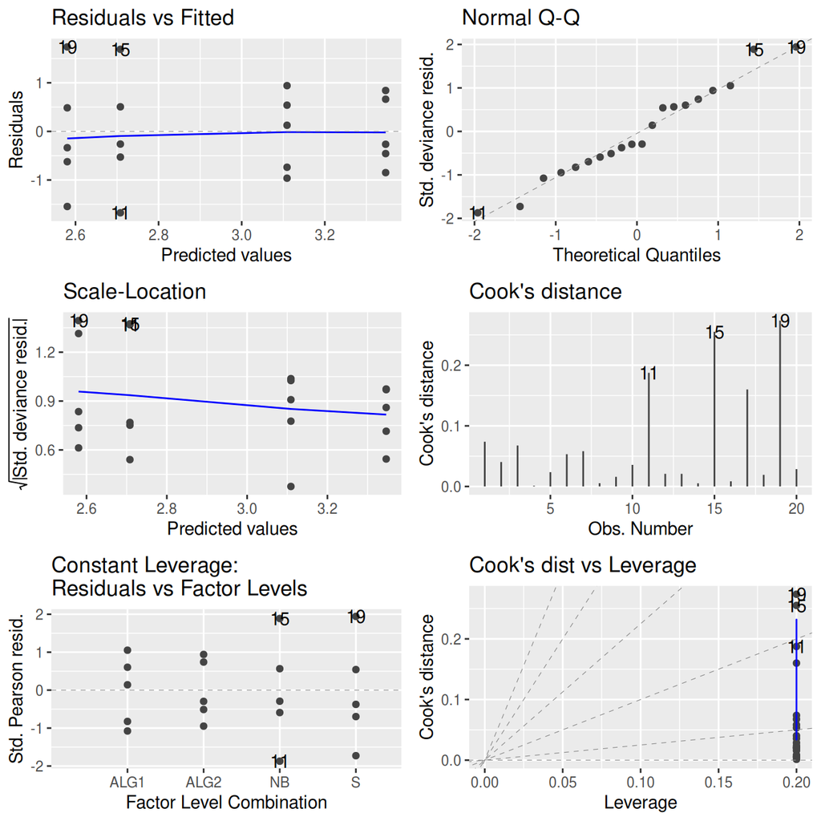

```r
day.glm1 %>% autoplot(which = 1:6)
```

**Conclusion:**

- there is not much alarming here
- note, there is no value in displaying leverage and leverage based diagnostics since leverage does not make much sense from categorical predictors. An observation must be in one of the levels - they cannot really be an outlier in this dimension.

## influence.measures

### Gaussian

```r
day.glm %>% influence.measures()
```

```
## Influence measures of
##   glm(formula = BARNACLE ~ TREAT, family = "gaussian", data = day) :
##
##       dfb.1_ dfb.TREATA dfb.TREATN dfb.TREATS   dffit cov.r  cook.d hat inf
## 1   6.05e-01  -4.28e-01  -4.28e-01  -4.28e-01  0.6053 1.115 0.08900 0.2
## 2  -4.38e-01   3.10e-01   3.10e-01   3.10e-01 -0.4378 1.326 0.04862 0.2
## 3  -5.77e-01   4.08e-01   4.08e-01   4.08e-01 -0.5766 1.152 0.08143 0.2
## 4   7.54e-02  -5.33e-02  -5.33e-02  -5.33e-02  0.0754 1.608 0.00151 0.2
## 5   3.31e-01  -2.34e-01  -2.34e-01  -2.34e-01  0.3313 1.442 0.02843 0.2
## 6   7.16e-17  -4.08e-01  -5.34e-17  -4.47e-17 -0.5766 1.152 0.08143 0.2
## 7  -7.51e-17   4.28e-01   5.60e-17   4.70e-17  0.6053 1.115 0.08900 0.2
## 8   2.19e-17  -1.25e-01  -1.63e-17  -1.37e-17 -0.1766 1.565 0.00824 0.2
## 9   3.79e-17  -2.16e-01  -2.82e-17  -2.37e-17 -0.3051 1.467 0.02423 0.2
## 10 -5.77e-17   3.29e-01   4.30e-17   3.61e-17  0.4650 1.293 0.05451 0.2
## 11  1.47e-17  -4.15e-17  -5.78e-01   0.00e+00 -0.8180 0.839 0.15141 0.2
## 12  4.54e-18  -1.28e-17  -1.79e-01   0.00e+00 -0.2533 1.512 0.01682 0.2
## 13 -4.54e-18   1.28e-17   1.79e-01   0.00e+00  0.2533 1.512 0.01682 0.2
## 14  2.25e-18  -6.38e-18  -8.90e-02   0.00e+00 -0.1259 1.591 0.00421 0.2
## 15 -1.77e-17   5.00e-17   6.98e-01   0.00e+00  0.9866 0.643 0.20609 0.2
## 16 -1.12e-18  -4.95e-18   8.12e-18  -1.07e-01 -0.1512 1.579 0.00606 0.2
## 17 -5.15e-18  -2.27e-17   3.73e-17  -4.91e-01 -0.6937 0.998 0.11373 0.2
## 18  1.69e-18   7.46e-18  -1.22e-17   1.61e-01  0.2276 1.532 0.01363 0.2
## 19  7.06e-18   3.12e-17  -5.11e-17   6.73e-01  0.9515 0.681 0.19448 0.2
## 20 -2.07e-18  -9.14e-18   1.50e-17  -1.97e-01 -0.2791 1.490 0.02036 0.2
```

### Poisson

```r
day.glm1 %>% influence.measures()
```

```
## Influence measures of
##   glm(formula = BARNACLE ~ TREAT, family = poisson(link = "log"),      data = day) :
##
##       dfb.1_ dfb.TREATA dfb.TREATN dfb.TREATS   dffit cov.r  cook.d hat inf
## 1   5.08e-01  -3.80e-01  -3.22e-01  -3.09e-01  0.5078 1.240 0.07380 0.2
## 2  -3.93e-01   2.94e-01   2.49e-01   2.39e-01 -0.3929 1.377 0.04032 0.2
## 3  -5.20e-01   3.89e-01   3.30e-01   3.17e-01 -0.5203 1.224 0.06752 0.2
## 4   6.59e-02  -4.93e-02  -4.17e-02  -4.01e-02  0.0659 1.611 0.00126 0.2
## 5   2.84e-01  -2.13e-01  -1.80e-01  -1.73e-01  0.2844 1.486 0.02358 0.2
## 6  -3.01e-17  -3.02e-01   2.01e-17   3.53e-17 -0.4548 1.305 0.05326 0.2
## 7   2.98e-17   2.99e-01  -1.99e-17  -3.50e-17  0.4508 1.310 0.05821 0.2
## 8  -9.16e-18  -9.20e-02   6.13e-18   1.08e-17 -0.1386 1.585 0.00539 0.2
## 9  -1.59e-17  -1.60e-01   1.06e-17   1.86e-17 -0.2403 1.522 0.01585 0.2
## 10  2.32e-17   2.33e-01  -1.55e-17  -2.72e-17  0.3511 1.422 0.03565 0.2
## 11 -2.42e-17   5.04e-17  -7.58e-01   3.04e-17 -0.9794 0.651 0.18750 0.2
## 12 -6.90e-18   1.43e-17  -2.16e-01   8.65e-18 -0.2787 1.491 0.02083 0.2
## 13  6.59e-18  -1.37e-17   2.06e-01  -8.26e-18  0.2663 1.501 0.02083 0.2
## 14 -3.38e-18   7.04e-18  -1.06e-01   4.24e-18 -0.1366 1.586 0.00521 0.2
## 15  2.45e-17  -5.10e-17   7.66e-01  -3.07e-17  0.9896 0.640 0.25521 0.2
## 16 -1.10e-18  -3.52e-18  -1.01e-17  -1.39e-01 -0.1758 1.566 0.00852 0.2
## 17 -5.54e-18  -1.78e-17  -5.08e-17  -7.03e-01 -0.8869 0.756 0.16004 0.2
## 18  1.59e-18   5.11e-18   1.46e-17   2.02e-01  0.2552 1.511 0.01918 0.2
## 19  6.41e-18   2.06e-17   5.88e-17   8.14e-01  1.0265 0.601 0.27367 0.2
## 20 -2.06e-18  -6.62e-18  -1.89e-17  -2.62e-01 -0.3301 1.443 0.02865 0.2
```

## Performance model checking

### Gaussian

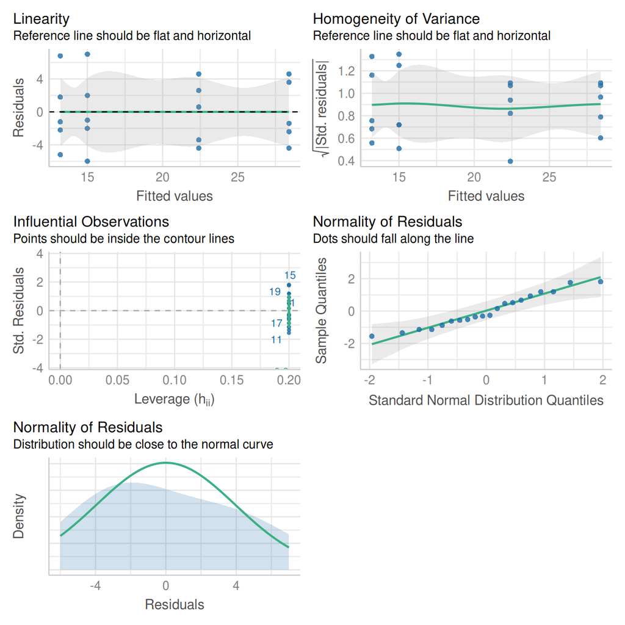

```r
day.glm %>% performance::check_model()
```

**Conclusion:**

- there is not much alarming here
- note, there is no value in displaying leverage and leverage based diagnostics since leverage does not make much sense from categorical predictors. An observation must be in one of the levels - they cannot really be an outlier in this dimension.

### Poisson

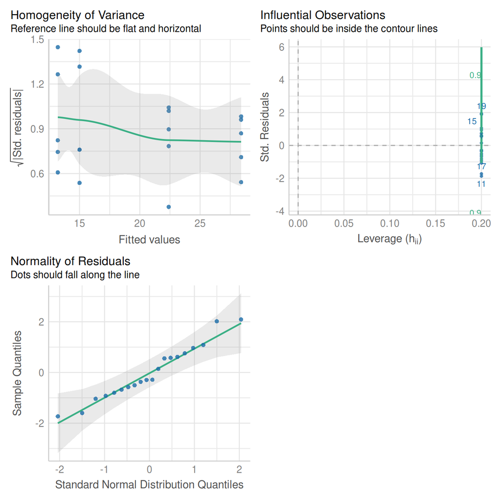

```r
day.glm1 %>% performance::check_model()
```

**Conclusion:**

- there is not much alarming here
- note, there is no value in displaying leverage and leverage based diagnostics since leverage does not make much sense from categorical predictors. An observation must be in one of the levels - they cannot really be an outlier in this dimension.

## DHARMa residuals

### Gaussian

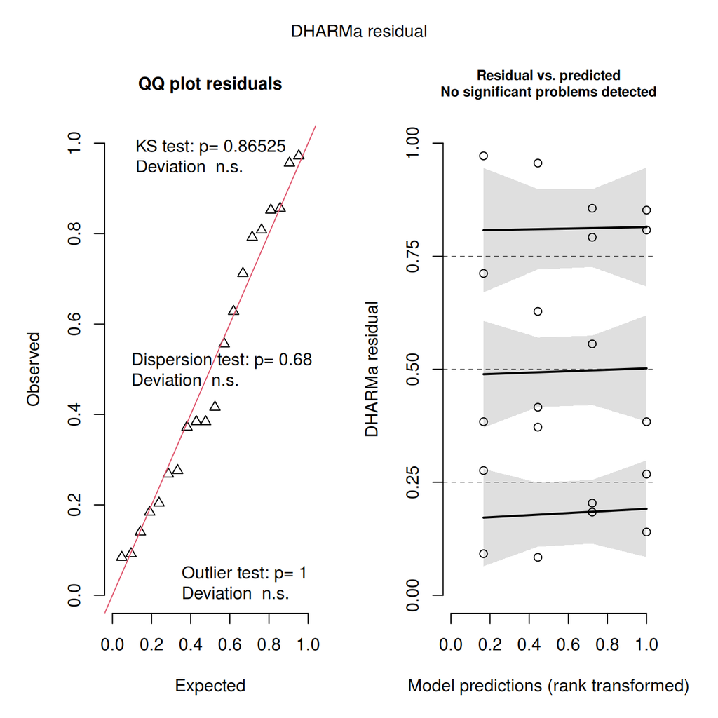

```r
day.resids <- day.glm %>% simulateResiduals(plot = TRUE)
```

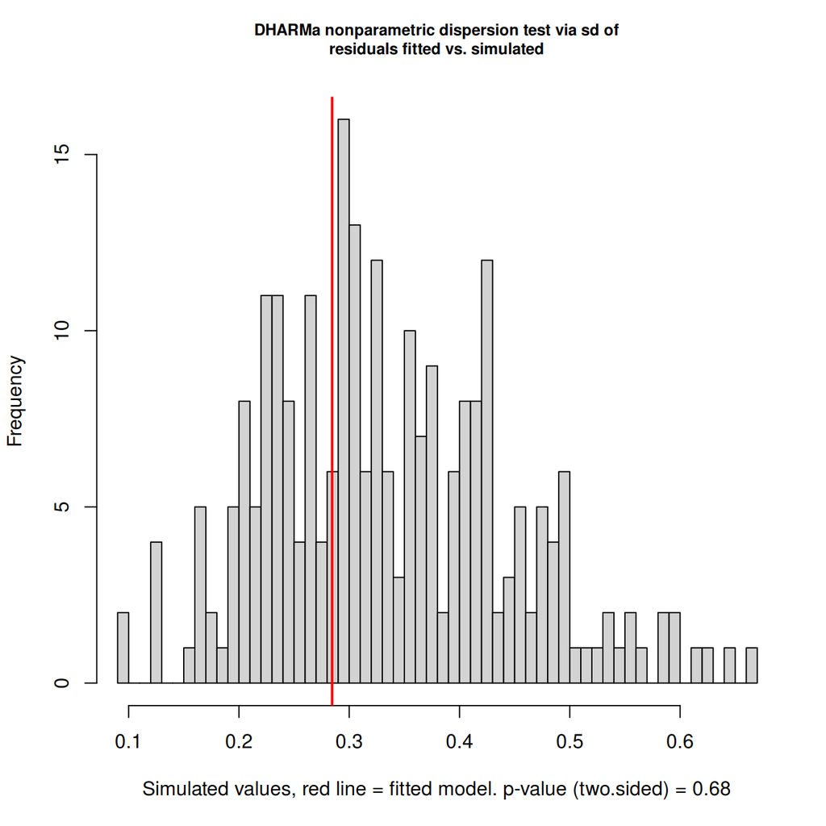

```
##
##  DHARMa nonparametric dispersion test via sd of residuals fitted vs.
##  simulated
##
## data:  simulationOutput
## dispersion = 0.84683, p-value = 0.68
## alternative hypothesis: two.sided
```

```r
day.resids %>% testDispersion()
```

**Conclusion:**

- there is not much alarming here

### Poisson

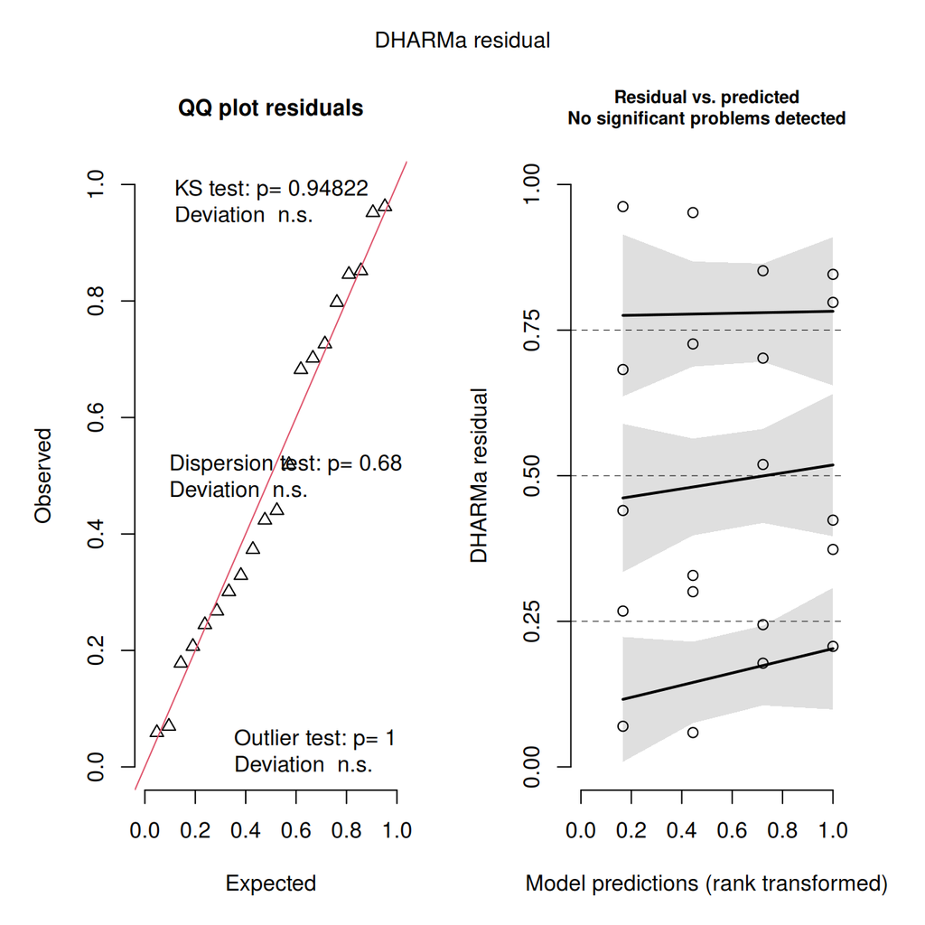

```r
day.resids <- day.glm1 %>% simulateResiduals(plot = TRUE)
```

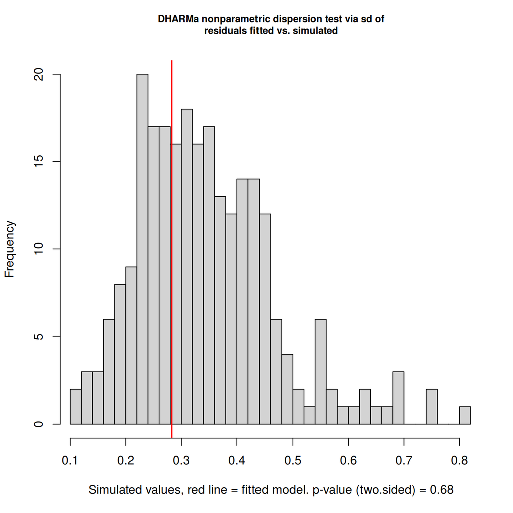

```
##
##  DHARMa nonparametric dispersion test via sd of residuals fitted vs.
##  simulated
##
## data:  simulationOutput
## dispersion = 0.81979, p-value = 0.68
## alternative hypothesis: two.sided
```

```r
day.resids %>% testDispersion()
```

**Conclusion:**

- there is not much alarming here

## Simple dispersion

### Gaussian

```r
## overdispersion
1 - pchisq(day.glm$deviance, day.glm$df.residual)
```

```
## [1] 0
```

```r
day.glm$deviance / day.glm$df.residual
```

```
## [1] 18.575
```

**Conclusion:**

- this is of little value as it is not really possible for a Gaussian model to be over-dispersed. Lets ignore this…

### Poisson

```r
1 - pchisq(day.glm1$deviance, day.glm1$df.residual)
```

```
## [1] 0.3719059
```

```r
day.glm1$deviance / day.glm1$df.residual
```

```
## [1] 1.075851
```

**Conclusion:**

- there is no evidence for a lack of model fit
- the estimated dispersion parameter is close to 1 suggesting no over-dispersion.

**Conclusion:**

- the various diagnostics suggest that the Poisson model is likely to be reliable.
- on the basis of the diagnostics, the Gaussian model would also be reliable. Nevertheless, we will only pursue the Gaussian model for the purpose of illustrating and interpreting the treatment effects and not because it is an appropriate model.

# Partial plots

## plot_model

### Gaussian

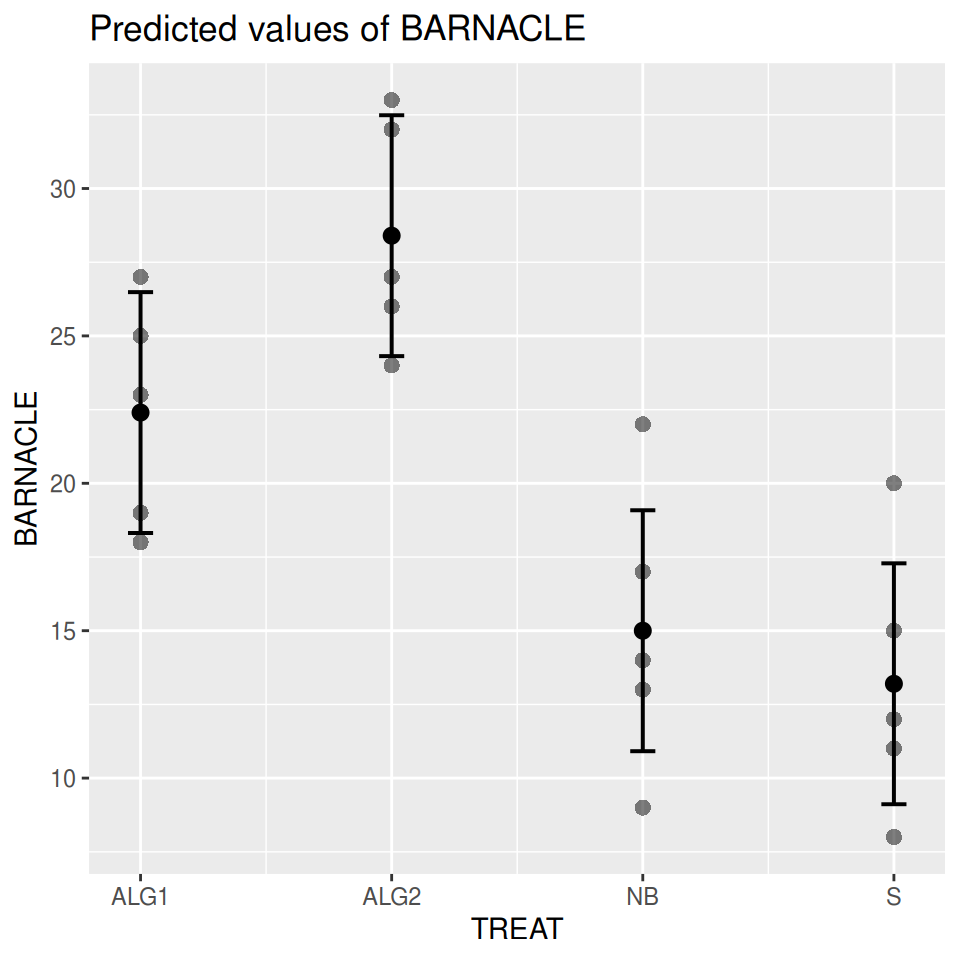

```r
day.glm %>% plot_model(type = "eff", show.data = TRUE)
```

### Poisson

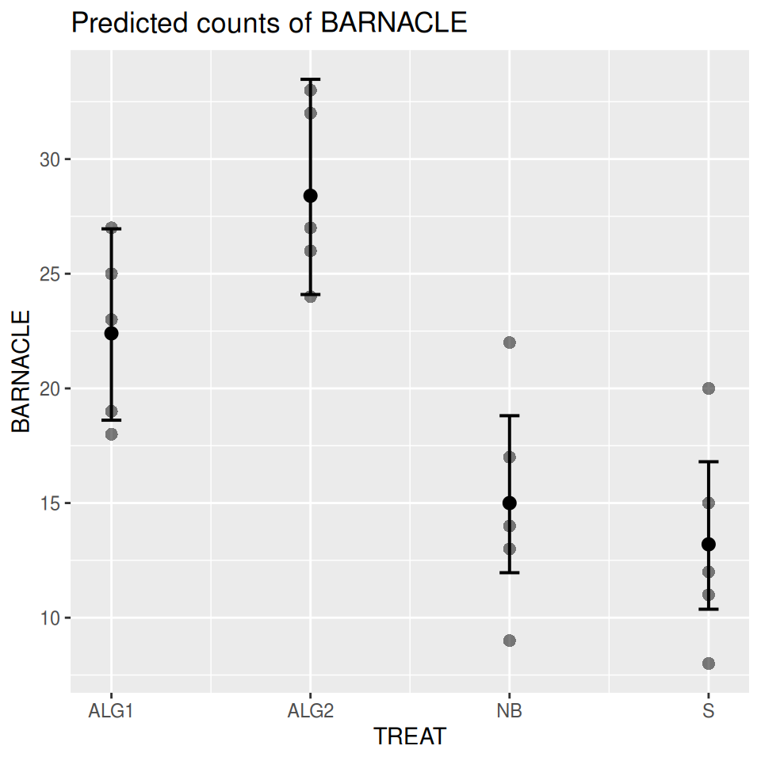

```r
day.glm1 %>% plot_model(type = "eff", show.data = TRUE)
```

## allEffects

### Gaussian

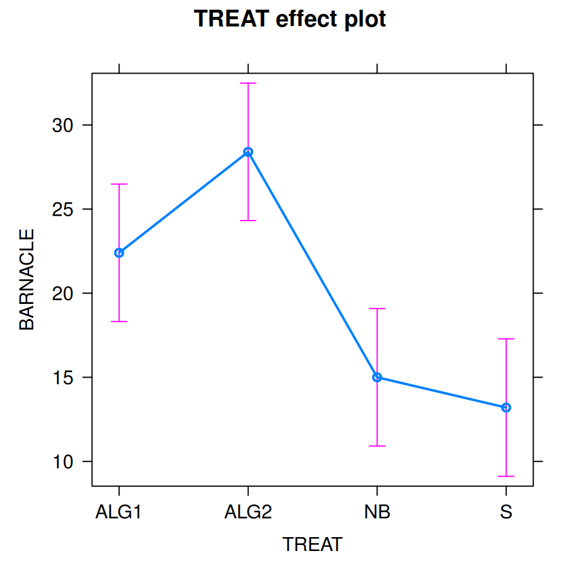

```r
day.glm %>%
  allEffects() %>%
  plot()
```

### Poisson

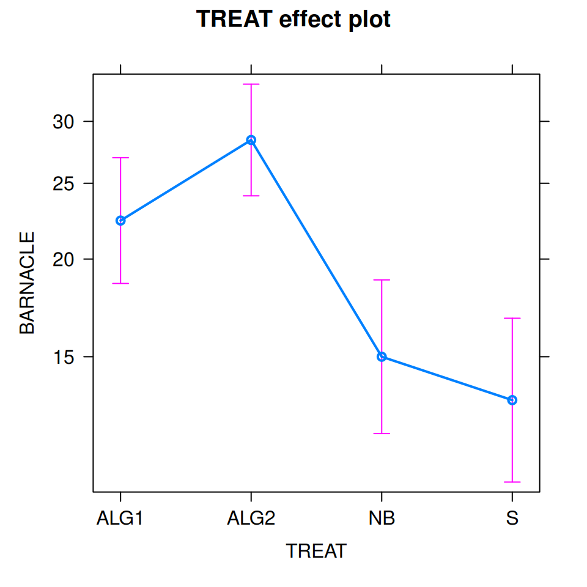

```r
day.glm1 %>%
  allEffects() %>%
  plot()
```

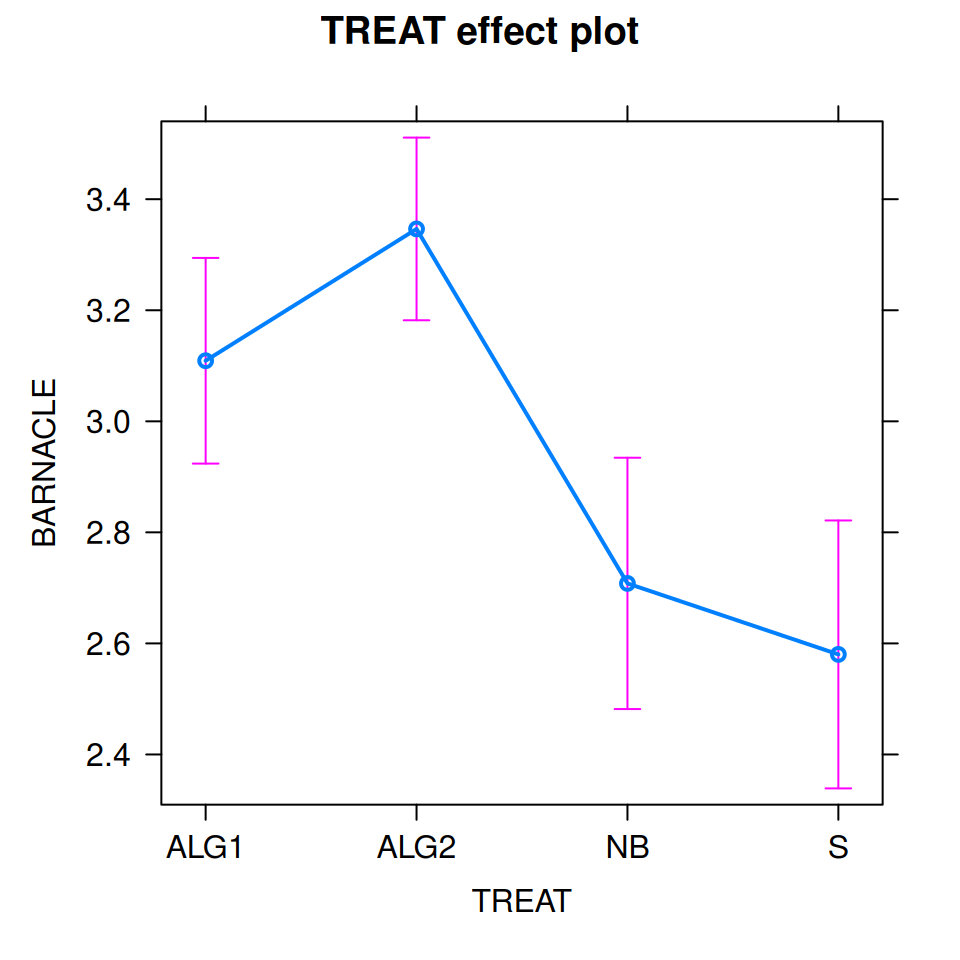

```r
allEffects(day.glm1, transformation = NULL) %>% plot()
```

## ggpredict

Predicted values are always on the response scale

### Gaussian

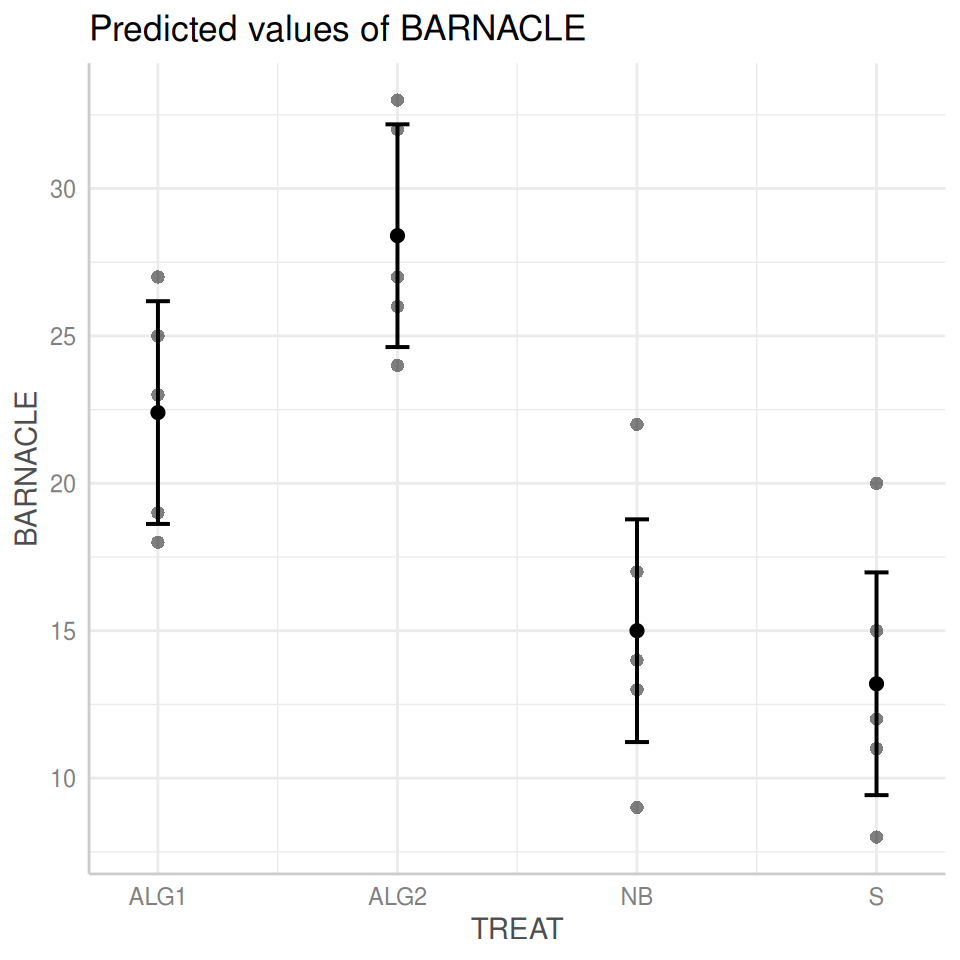

```r
day.glm %>%
  ggpredict() %>%
  plot(add.data = TRUE, jitter = FALSE)
```

### Poisson

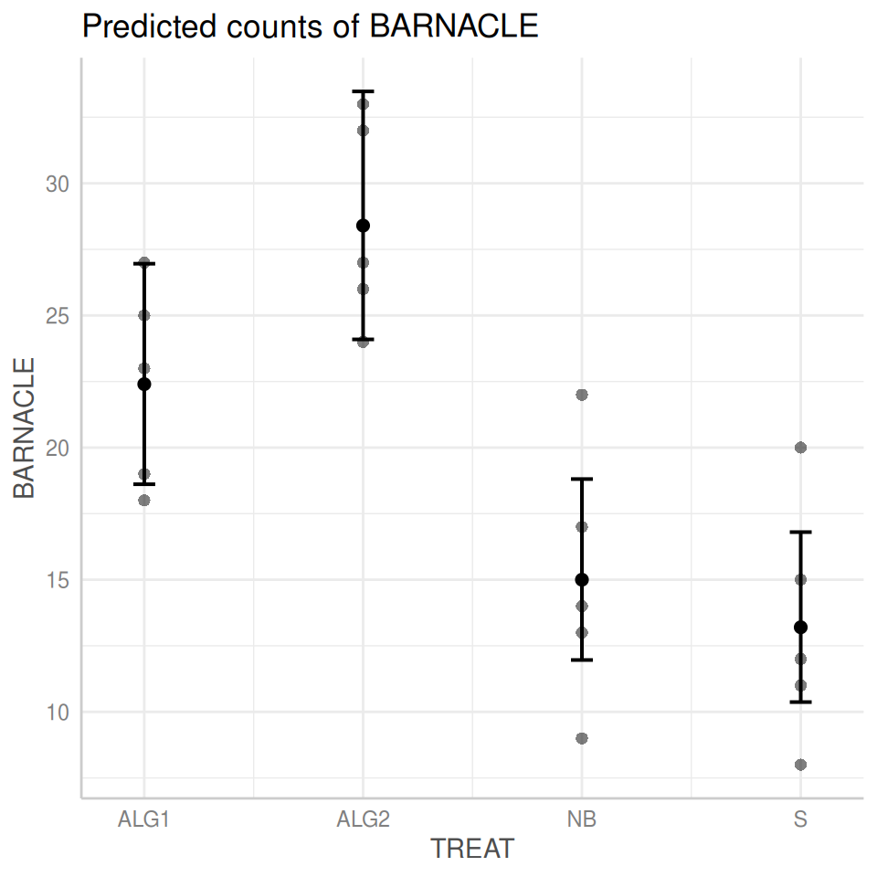

```r
day.glm1 %>%
  ggpredict() %>%
  plot(add.data = TRUE, jitter = FALSE)
```

```r
## back.transform only applies to response transformations, not link functions
## day.glm1 %>% ggpredict(back.transform = FALSE) %>% plot()
```

## ggemmeans

Predicted values are always on the response scale

### Gaussian

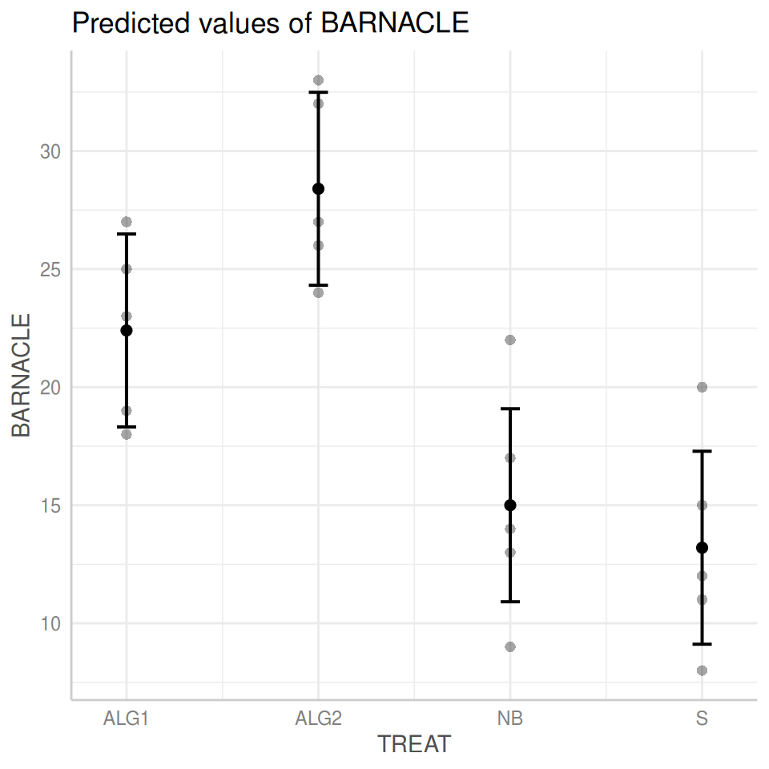

```r
day.glm %>%
  ggemmeans(~TREAT) %>%
  plot(add.data = TRUE, jitter = FALSE)
```

### Poisson

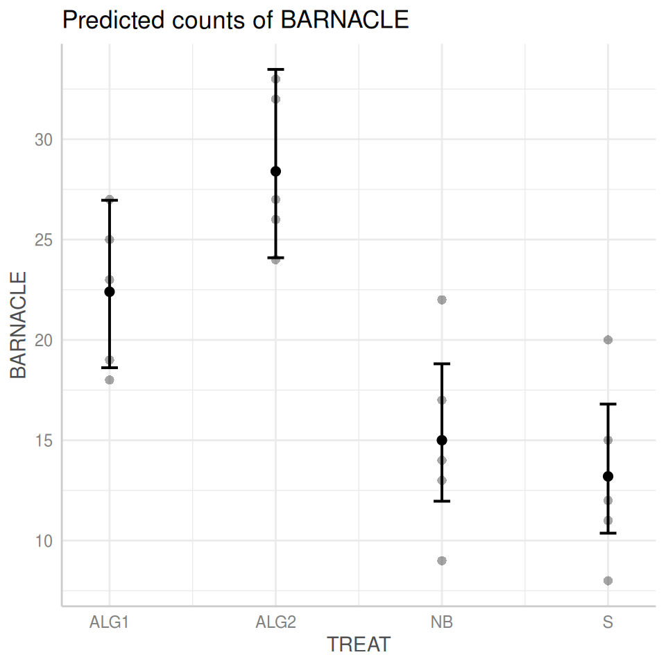

```r
day.glm1 %>%
  ggemmeans(~TREAT) %>%
  plot(add.data = TRUE, jitter = FALSE)
```

```r
## back.transform only applies to response transformations, not link functions
## day.glm1 %>% ggemmeans(back.transform = FALSE) %>% plot()
```

# Model investigation / hypothesis testing

## Gaussian

### summary

```r
day.glm %>% summary()
```

```
##
## Call:
## glm(formula = BARNACLE ~ TREAT, family = "gaussian", data = day)
##
## Deviance Residuals:
##    Min      1Q  Median      3Q     Max
##  -6.00   -2.65   -1.10    2.85    7.00
##
## Coefficients:
##             Estimate Std. Error t value Pr(>|t|)
## (Intercept)   22.400      1.927  11.622 3.27e-09 ***
## TREATALG2      6.000      2.726   2.201  0.04275 *
## TREATNB       -7.400      2.726  -2.715  0.01530 *
## TREATS        -9.200      2.726  -3.375  0.00386 **
## ---
## Signif. codes:  0 '***' 0.001 '**' 0.01 '*' 0.05 '.' 0.1 ' ' 1
##
## (Dispersion parameter for gaussian family taken to be 18.575)
##
##     Null deviance: 1033.8  on 19  degrees of freedom
## Residual deviance:  297.2  on 16  degrees of freedom
## AIC: 120.73
##
## Number of Fisher Scoring iterations: 2
```

**Conclusions**:

- the estimated y-intercept (mean number of newly recruited barnacles in the ALG1 group) is 22.4.
- there is expected to be 6 more newly recruited barnacles on the ALG2 substrate than the ALG1 substrate.
- there is expected to be -7.4 and -9.2 fewer newly recruited barnacles on the NB and S substrates respectively than the ALG1 substrate.

### confint

```r
day.glm %>% confint()
```

```
##                  2.5 %    97.5 %
## (Intercept)  18.622300 26.177700
## TREATALG2     0.657525 11.342475
## TREATNB     -12.742475 -2.057525
## TREATS      -14.542475 -3.857525
```

### tidy

```r
day.glm %>% tidy(conf.int = TRUE)
```

| term | estimate | std.error | statistic | p.value | conf.low | conf.high |
| --- | --- | --- | --- | --- | --- | --- |
| (Intercept) | 22.4 | 1.927434 | 11.621672 | 3.267990e-09 | 18.622300 | 26.177700 |
| TREATALG2 | 6.0 | 2.725803 | 2.201187 | 4.274792e-02 | 0.657525 | 11.342475 |
| TREATNB | -7.4 | 2.725803 | -2.714797 | 1.530094e-02 | -12.742475 | -2.057525 |
| TREATS | -9.2 | 2.725803 | -3.375153 | 3.857157e-03 | -14.542475 | -3.857525 |

### tab_model

```r
# warning this is only appropriate for html output
day.glm %>% sjPlot::tab_model(show.se = TRUE, show.aic = TRUE)
```

|  | BARNACLE |  |  |  |
| --- | --- | --- | --- | --- |
| Predictors | Estimates | std. Error | CI | p |
| (Intercept) | 22.40 | 1.93 | 18.62 – 26.18 | **<0.001** |
| TREAT [ALG2] | 6.00 | 2.73 | 0.66 – 11.34 | **0.028** |
| TREAT [NB] | -7.40 | 2.73 | -12.74 – -2.06 | **0.007** |
| TREAT [S] | -9.20 | 2.73 | -14.54 – -3.86 | **0.001** |
| Observations | 20 |  |  |  |
| R<sup>2</sup> | 0.713 |  |  |  |
| AIC | 120.731 |  |  |  |

## Poisson

### summary

```r
day.glm1 %>% summary()
```

```
##
## Call:
## glm(formula = BARNACLE ~ TREAT, family = poisson(link = "log"),
##     data = day)
##
## Deviance Residuals:
##     Min       1Q   Median       3Q      Max
## -1.6748  -0.6522  -0.2630   0.5699   1.7380
##
## Coefficients:
##             Estimate Std. Error z value Pr(>|z|)
## (Intercept)  3.10906    0.09449  32.903  < 2e-16 ***
## TREATALG2    0.23733    0.12638   1.878 0.060387 .
## TREATNB     -0.40101    0.14920  -2.688 0.007195 **
## TREATS      -0.52884    0.15518  -3.408 0.000654 ***
## ---
## Signif. codes:  0 '***' 0.001 '**' 0.01 '*' 0.05 '.' 0.1 ' ' 1
##
## (Dispersion parameter for poisson family taken to be 1)
##
##     Null deviance: 54.123  on 19  degrees of freedom
## Residual deviance: 17.214  on 16  degrees of freedom
## AIC: 120.34
##
## Number of Fisher Scoring iterations: 4
```

### confint

```r
day.glm1 %>% confint()
```

```
##                    2.5 %     97.5 %
## (Intercept)  2.917958584  3.2887098
## TREATALG2   -0.009471895  0.4865512
## TREATNB     -0.696806649 -0.1108759
## TREATS      -0.837588039 -0.2280991
```

```r
day.glm1 %>%
  confint() %>%
  exp()
```

```
##                  2.5 %     97.5 %
## (Intercept) 18.5034756 26.8082525
## TREATALG2    0.9905728  1.6266964
## TREATNB      0.4981736  0.8950498
## TREATS       0.4327530  0.7960454
```

### tidy

```r
day.glm1 %>% tidy(conf.int = TRUE)
```

| term | estimate | std.error | statistic | p.value | conf.low | conf.high |
| --- | --- | --- | --- | --- | --- | --- |
| (Intercept) | 3.1090610 | 0.09449112 | 32.903208 | 1.977474e-237 | 2.917958584 | 3.2887098 |
| TREATALG2 | 0.2373282 | 0.12637573 | 1.877957 | 6.038705e-02 | -0.009471895 | 0.4865512 |
| TREATNB | -0.4010108 | 0.14920422 | -2.687664 | 7.195385e-03 | -0.696806649 | -0.1108759 |
| TREATS | -0.5288441 | 0.15517757 | -3.407993 | 6.544249e-04 | -0.837588039 | -0.2280991 |

```r
day.glm1 %>% tidy(conf.int = TRUE, exponentiate = TRUE)
```

| term | estimate | std.error | statistic | p.value | conf.low | conf.high |
| --- | --- | --- | --- | --- | --- | --- |
| (Intercept) | 22.4000000 | 0.09449112 | 32.903208 | 1.977474e-237 | 18.5034756 | 26.8082525 |
| TREATALG2 | 1.2678571 | 0.12637573 | 1.877957 | 6.038705e-02 | 0.9905728 | 1.6266964 |
| TREATNB | 0.6696429 | 0.14920422 | -2.687664 | 7.195385e-03 | 0.4981736 | 0.8950498 |
| TREATS | 0.5892857 | 0.15517757 | -3.407993 | 6.544249e-04 | 0.4327530 | 0.7960454 |

```r
day.glm1 %>%
  tidy(conf.int = TRUE, exponentiate = TRUE) %>%
  kable()
```

| term | estimate | std.error | statistic | p.value | conf.low | conf.high |
| --- | --- | --- | --- | --- | --- | --- |
| (Intercept) | 22.4000000 | 0.0944911 | 32.903208 | 0.0000000 | 18.5034756 | 26.8082525 |
| TREATALG2 | 1.2678571 | 0.1263757 | 1.877957 | 0.0603870 | 0.9905728 | 1.6266964 |
| TREATNB | 0.6696429 | 0.1492042 | -2.687664 | 0.0071954 | 0.4981736 | 0.8950498 |
| TREATS | 0.5892857 | 0.1551776 | -3.407993 | 0.0006544 | 0.4327530 | 0.7960454 |

### tab_model

```r
# warning this is only appropriate for html output
day.glm1 %>% sjPlot::tab_model(show.se = TRUE, show.aic = TRUE)
```

|  | BARNACLE |  |  |  |
| --- | --- | --- | --- | --- |
| Predictors | Incidence Rate Ratios | std. Error | CI | p |
| (Intercept) | 22.40 | 2.12 | 18.50 – 26.81 | **<0.001** |
| TREAT [ALG2] | 1.27 | 0.16 | 0.99 – 1.63 | 0.060 |
| TREAT [NB] | 0.67 | 0.10 | 0.50 – 0.90 | **0.007** |
| TREAT [S] | 0.59 | 0.09 | 0.43 – 0.80 | **0.001** |
| Observations | 20 |  |  |  |
| R<sup>2</sup> Nagelkerke | 0.902 |  |  |  |
| AIC | 120.340 |  |  |  |

# Predictions

The estimated coefficients as presented in the summary tables above highlight very specific comparisons. However, there are other possible comparisons that we might be interested in. For example, whist the treatment effects compare each of the substrate types against the first level (ALG1), we might also be interested in the differences between (for example) the two bare substrates (NB and S).

To get at more of the comparisons we have two broad approaches:

- compare all substrates to each other in a pairwise manner.
  - importantly, given that the probability of a Type I error (falsely rejecting a null hypothesis) is set at 0.05 per comparison, when there are multiple comparisons, the family-wise Type I error (probability of at least one false rejection amongst all comparisons) rate compounds. It is important to attempt to constrain this family-wise Type I error rate. One approach to do this is a Tukey’s test.
  - keep in mind that in order to constrain the family-wise Type I error rate at 0.05, the power of each individual comparison is reduced (individual Type II error rates increased).
- define a small set of specific comparisons. There should be a maximum of $p-1$ comparisons defined (where $p$ is the number of levels of the categorical predictors) and each comparison should be independent of one another.

We will now only pursue the Poisson model.

## Post-hoc test (Tukey’s)

```r
## Comparisons on a fractional scale
day.glm1 %>%
  emmeans(~TREAT, type = "response") %>%
  pairs()
```

```
##  contrast    ratio     SE  df null z.ratio p.value
##  ALG1 / ALG2 0.789 0.0997 Inf    1  -1.878  0.2375
##  ALG1 / NB   1.493 0.2228 Inf    1   2.688  0.0362
##  ALG1 / S    1.697 0.2633 Inf    1   3.408  0.0037
##  ALG2 / NB   1.893 0.2703 Inf    1   4.472  <.0001
##  ALG2 / S    2.152 0.3205 Inf    1   5.143  <.0001
##  NB / S      1.136 0.1918 Inf    1   0.757  0.8735
##
## P value adjustment: tukey method for comparing a family of 4 estimates
## Tests are performed on the log scale
```

```r
## Including confidence intervals
day.glm1 %>%
  emmeans(~TREAT, type = "response") %>%
  pairs() %>%
  confint()
```

|  | contrast | ratio | SE | df | asymp.LCL | asymp.UCL |
| --- | --- | --- | --- | --- | --- | --- |
| 1 | ALG1 / ALG2 | 0.7887324 | 0.09967663 | Inf | 0.5700727 | 1.091262 |
| 2 | ALG1 / NB | 1.4933333 | 0.22281164 | Inf | 1.0178579 | 2.190919 |
| 3 | ALG1 / S | 1.6969697 | 0.26333163 | Inf | 1.1390425 | 2.528181 |
| 4 | ALG2 / NB | 1.8933333 | 0.27026020 | Inf | 1.3120981 | 2.732045 |
| 5 | ALG2 / S | 2.1515152 | 0.32052349 | Inf | 1.4673367 | 3.154707 |
| 6 | NB / S | 1.1363636 | 0.19178922 | Inf | 0.7365680 | 1.753161 |

```r
## Confidence intervals and p-values
day.glm1 %>%
  emmeans(~TREAT, type = "response") %>%
  pairs() %>%
  summary(infer = TRUE)
```

|  | contrast | ratio | SE | df | asymp.LCL | asymp.UCL | null | z.ratio | p.value |
| --- | --- | --- | --- | --- | --- | --- | --- | --- | --- |
| 1 | ALG1 / ALG2 | 0.7887324 | 0.09967663 | Inf | 0.5700727 | 1.091262 | 1 | -1.8779570 | 2.375154e-01 |
| 2 | ALG1 / NB | 1.4933333 | 0.22281164 | Inf | 1.0178579 | 2.190919 | 1 | 2.6876636 | 3.620380e-02 |
| 3 | ALG1 / S | 1.6969697 | 0.26333163 | Inf | 1.1390425 | 2.528181 | 1 | 3.4079934 | 3.657569e-03 |
| 4 | ALG2 / NB | 1.8933333 | 0.27026020 | Inf | 1.3120981 | 2.732045 | 1 | 4.4719437 | 4.584635e-05 |
| 5 | ALG2 / S | 2.1515152 | 0.32052349 | Inf | 1.4673367 | 3.154707 | 1 | 5.1429347 | 1.615786e-06 |
| 6 | NB / S | 1.1363636 | 0.19178922 | Inf | 0.7365680 | 1.753161 | 1 | 0.7574211 | 8.735131e-01 |

```r
## Lets store this for late

day.pairwise <- day.glm1 %>%
  emmeans(~TREAT, type = "response") %>%
  pairs() %>%
  summary(infer = TRUE) %>%
  as.data.frame()
```

**Conclusions:**

- the contrasts section of the output indicates that there is evidence of:
- ALG1 has 1.49 fold (0.49) more newly recruited barnacles than the NB substrate
- ALG1 has 1.7 fold (0.7) more newly recruited barnacles than the S substrate
- ALG2 has 1.89 fold (0.89) more newly recruited barnacles than the NB substrate
- ALG2 has 2.15 fold (1.15) more newly recruited barnacles than the S substrate
- ALG1 was not found to be different to ALG2 and NB was not found to be different to S

## Planned contrasts

Define your own

Compare:

1. ALG1 vs ALG2
2. NB vs S
3. average of ALG1+ALG2 vs NB+S

| Levels | Alg1 vs Alg2 | NB vs S | Alg vs Bare |
| --- | --- | --- | --- |
| Alg1 | 1 | 0 | 0.5 |
| Alg2 | -1 | 0 | 0.5 |
| NB | 0 | 1 | -0.5 |
| S | 0 | -1 | -0.5 |

```r
##      Alg1_Alg2 NB_S Alg_Bare
## ALG1         1    0      0.5
## ALG2        -1    0      0.5
## NB           0    1     -0.5
## S            0   -1     -0.5
cmat <- (cbind(
  "Alg1_Alg2" = c(1, -1, 0, 0),
  "NB_S" = c(0, 0, 1, -1),
  "Alg_Bare" = c(0.5, 0.5, -0.5, -0.5)
))
cmat
```

```
##      Alg1_Alg2 NB_S Alg_Bare
## [1,]         1    0      0.5
## [2,]        -1    0      0.5
## [3,]         0    1     -0.5
## [4,]         0   -1     -0.5
```

It is important that each of the comparisons are independent of one another. We can test this by exploring the cross products of the contrast matrix. Independent comparisons will have a cross product of 0. So if all of the values in the lower (and equivalently, the upper) triangle of the cross product matrix are 0, then all comparisons are independent. Those that are not 0, indicate a lack of independence and a need to remove one of the comparisons from the set of contrasts. Note, we can ignore the diagonal values.

```r
crossprod(cmat)
```

```
##           Alg1_Alg2 NB_S Alg_Bare
## Alg1_Alg2         2    0        0
## NB_S              0    2        0
## Alg_Bare          0    0        1
```

**Conclusions:**

- all comparisons are independent

```r
day.glm1 %>% emmeans(~TREAT, contr = list(TREAT = cmat), type = "response")
```

```
## $emmeans
##  TREAT rate   SE  df asymp.LCL asymp.UCL
##  ALG1  22.4 2.12 Inf      18.6      27.0
##  ALG2  28.4 2.38 Inf      24.1      33.5
##  NB    15.0 1.73 Inf      12.0      18.8
##  S     13.2 1.62 Inf      10.4      16.8
##
## Confidence level used: 0.95
## Intervals are back-transformed from the log scale
##
## $contrasts
##  contrast        ratio     SE  df null z.ratio p.value
##  TREAT.Alg1_Alg2 0.789 0.0997 Inf    1  -1.878  0.0604
##  TREAT.NB_S      1.136 0.1918 Inf    1   0.757  0.4488
##  TREAT.Alg_Bare  1.792 0.1890 Inf    1   5.536  <.0001
##
## Tests are performed on the log scale
```

```r
day.glm1 %>%
  emmeans(~TREAT, type = "response") %>%
  contrast(method = list(TREAT = cmat)) %>%
  summary(infer = TRUE)
```

|  | contrast | ratio | SE | df | asymp.LCL | asymp.UCL | null | z.ratio | p.value |
| --- | --- | --- | --- | --- | --- | --- | --- | --- | --- |
| 1 | TREAT.Alg1_Alg2 | 0.7887324 | 0.09967663 | Inf | 0.6156848 | 1.010418 | 1 | -1.8779570 | 6.038705e-02 |
| 2 | TREAT.NB_S | 1.1363636 | 0.19178922 | Inf | 0.8163120 | 1.581898 | 1 | 0.7574211 | 4.487976e-01 |
| 3 | TREAT.Alg_Bare | 1.7924646 | 0.18896620 | Inf | 1.4578564 | 2.203872 | 1 | 5.5357370 | 3.099224e-08 |

```r
## what about absolute differences
day.glm1 %>%
  emmeans(~TREAT, type = "link") %>%
  regrid() %>%
  contrast(method = list(TREAT = cmat)) %>%
  summary(infer = TRUE)
```

|  | contrast | estimate | SE | df | asymp.LCL | asymp.UCL | z.ratio | p.value |
| --- | --- | --- | --- | --- | --- | --- | --- | --- |
| 1 | TREAT.Alg1_Alg2 | -6.0 | 3.187475 | Inf | -12.247337 | 0.2473372 | -1.8823674 | 5.978615e-02 |
| 2 | TREAT.NB_S | 1.8 | 2.374868 | Inf | -2.854656 | 6.4546555 | 0.7579369 | 4.484888e-01 |
| 3 | TREAT.Alg_Bare | 11.3 | 1.987461 | Inf | 7.404649 | 15.1953511 | 5.6856475 | 1.303180e-08 |

**Conclusions:**

- the number of newly recruited barnacles was not found to be significantly different between ALG1 and ALG2 substrates
- the number of newly recruited barnacles was not found to be significantly different between NB and S substrates
- the number of newly recruited barnacles was found to be significantly higher in the algael substrates than the bare substrates
  - the algael substrates attracted 1.79 fold (79%) more newly recruited barnacles than the bare substrates.

If you want to express the comparisons on an absolute scale…

|  | contrast | estimate | SE | df | asymp.LCL | asymp.UCL | z.ratio | p.value |
| --- | --- | --- | --- | --- | --- | --- | --- | --- |
| 1 | TREAT.Alg1_Alg2 | -6.0 | 3.187475 | Inf | -12.247337 | 0.2473372 | -1.8823674 | 5.978615e-02 |
| 2 | TREAT.NB_S | 1.8 | 2.374868 | Inf | -2.854656 | 6.4546555 | 0.7579369 | 4.484888e-01 |
| 3 | TREAT.Alg_Bare | 11.3 | 1.987461 | Inf | 7.404649 | 15.1953511 | 5.6856475 | 1.303180e-08 |

# Summary figures

## emmeans

```r
newdata <- day.glm1 %>%
  emmeans(~TREAT, type = "response") %>%
  as.data.frame()
newdata
```

|  | TREAT | rate | SE | df | asymp.LCL | asymp.UCL |
| --- | --- | --- | --- | --- | --- | --- |
| 1 | ALG1 | 22.4 | 2.116601 | Inf | 18.61303 | 26.95746 |
| 2 | ALG2 | 28.4 | 2.383275 | Inf | 24.09279 | 33.47724 |
| 3 | NB | 15.0 | 1.732051 | Inf | 11.96198 | 18.80960 |
| 4 | S | 13.2 | 1.624807 | Inf | 10.37047 | 16.80156 |

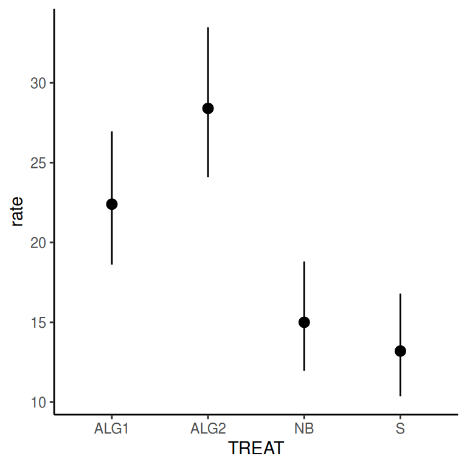

```r
## A quick version
ggplot(newdata, aes(y = rate, x = TREAT)) +
  geom_pointrange(aes(ymin = asymp.LCL, ymax = asymp.UCL)) +
  theme_classic()
```

A more thorough version that also includes the Tukey’s test

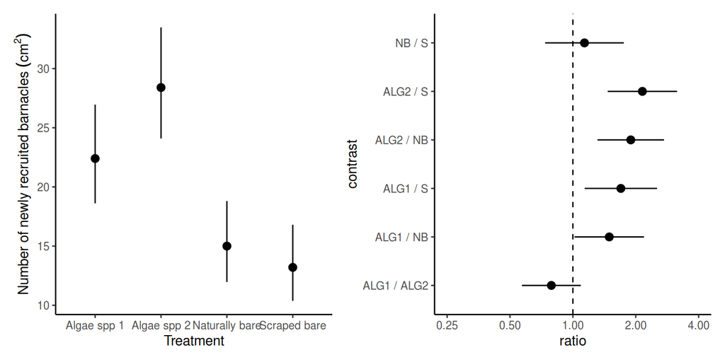

```r
g1 <- ggplot(newdata, aes(y = rate, x = TREAT)) +
  geom_pointrange(aes(ymin = asymp.LCL, ymax = asymp.UCL)) +
  geom_point() +
  scale_x_discrete("Treatment",
    breaks = c("ALG1", "ALG2", "NB", "S"),
    labels = c("Algae spp 1", "Algae spp 2", "Naturally bare", "Scraped bare")
  ) +
  scale_y_continuous(expression(Number ~ of ~ newly ~ recruited ~ barnacles ~ (cm^2))) +
  theme_classic()

g2 <- day.pairwise %>%
  ggplot(aes(y = ratio, x = contrast)) +
  geom_vline(xintercept = 1, linetype = "dashed") +
  geom_pointrange(aes(xmin = asymp.LCL, xmax = asymp.UCL)) +
  scale_y_continuous(
    trans = scales::log2_trans(),
    breaks = scales::breaks_log(base = 2)
  ) +
  theme_classic()

g2 <- day.pairwise %>%
  ggplot(aes(y = ratio, x = contrast)) +
  geom_hline(yintercept = 1, linetype = "dashed") +
  geom_pointrange(aes(ymin = asymp.LCL, ymax = asymp.UCL)) +
  scale_y_continuous(trans = scales::log2_trans(), breaks = scales::breaks_log(base = 2)) +
  coord_flip(ylim = c(0.25, 4)) +
  theme_classic()

g1 + g2
```

## manually

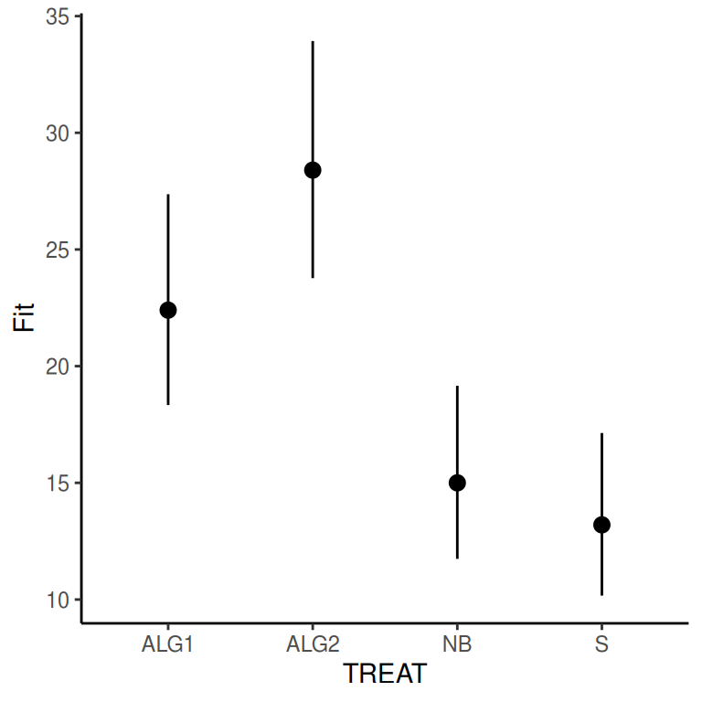

```r
newdata <- with(day, data.frame(TREAT = levels(TREAT)))
Xmat <- model.matrix(~TREAT, newdata)
coefs <- coef(day.glm1)

fit <- as.vector(coefs %*% t(Xmat))
se <- sqrt(diag(Xmat %*% vcov(day.glm1) %*% t(Xmat)))
q <- qt(0.975, df = df.residual(day.glm1))
newdata <- newdata %>%
  mutate(
    Fit = exp(fit),
    Lower = exp(fit - q * se),
    Upper = exp(fit + q * se)
  )
## A quick version
ggplot(newdata, aes(y = Fit, x = TREAT)) +
  geom_pointrange(aes(ymin = Lower, ymax = Upper)) +
  theme_classic()
```

A more thorough version that also includes the Tukey’s test

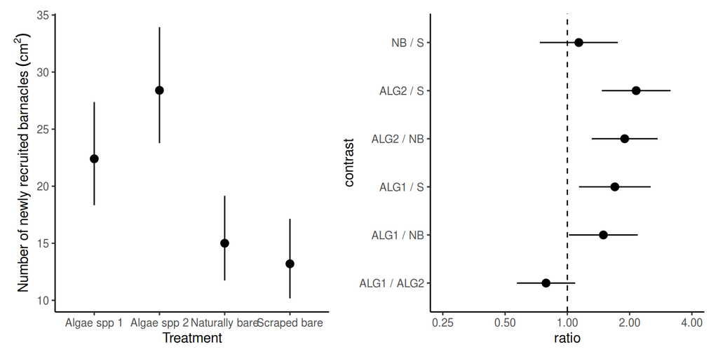

```r
g1 <- ggplot(newdata, aes(y = Fit, x = TREAT)) +
  geom_pointrange(aes(ymin = Lower, ymax = Upper)) +
  geom_point() +
  scale_x_discrete("Treatment",
    breaks = c("ALG1", "ALG2", "NB", "S"),
    labels = c("Algae spp 1", "Algae spp 2", "Naturally bare", "Scraped bare")
  ) +
  scale_y_continuous(expression(Number ~ of ~ newly ~ recruited ~ barnacles ~ (cm^2))) +
  theme_classic()

g2 <- day.pairwise %>%
  ggplot(aes(y = ratio, x = contrast)) +
  geom_hline(yintercept = 1, linetype = "dashed") +
  geom_pointrange(aes(ymin = asymp.LCL, ymax = asymp.UCL)) +
  scale_y_continuous(trans = scales::log2_trans(), breaks = scales::breaks_log(base = 2)) +
  coord_flip(ylim = c(0.25, 4)) +
  theme_classic()

g1 + g2
```

# References

Quinn, G. P., and K. J. Keough. 2002. *Experimental Design and Data Analysis for Biologists*. London: Cambridge University Press.